# Когортный анализ: удержание, конверсия, окупаемость.

#### Обзор и предобработка данных о рекламных расходах

```python
costs.head()
```

|  | dt | Channel | costs |
| --- | --- | --- | --- |
| 0 | 2019-05-01 | FaceBoom | 113.3 |
| 1 | 2019-05-02 | FaceBoom | 78.1 |
| 2 | 2019-05-03 | FaceBoom | 85.8 |
| 3 | 2019-05-04 | FaceBoom | 136.4 |
| 4 | 2019-05-05 | FaceBoom | 122.1 |

```python
costs.columns = costs.columns.str.lower()
costs.head()
```

|  | dt | channel | costs |
| --- | --- | --- | --- |
| 0 | 2019-05-01 | FaceBoom | 113.3 |
| 1 | 2019-05-02 | FaceBoom | 78.1 |
| 2 | 2019-05-03 | FaceBoom | 85.8 |
| 3 | 2019-05-04 | FaceBoom | 136.4 |
| 4 | 2019-05-05 | FaceBoom | 122.1 |

```python
costs.duplicated().sum()
```

```
0
```

```python
costs.info()
```

```
<class 'pandas.core.frame.DataFrame'>
RangeIndex: 1800 entries, 0 to 1799
Data columns (total 3 columns):
 #   Column   Non-Null Count  Dtype
---  ------   --------------  -----
 0   dt       1800 non-null   object
 1   channel  1800 non-null   object
 2   costs    1800 non-null   float64
dtypes: float64(1), object(2)
memory usage: 42.3+ KB
```

**По изучении данных обнаружили:**

- в данных отсутствуют пропуски и дубликаты;
- скорректировали названия столбцов;
- необходимо поменять формат дат событий.

##### Данные о рекламных источниках

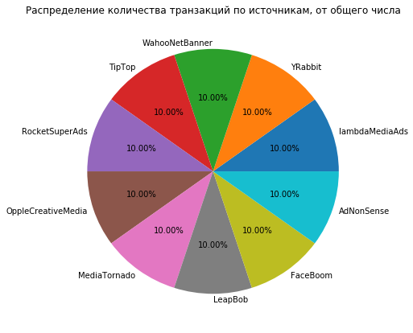

```python
costs.groupby('channel')['dt'].count().sort_values(ascending=False).\
plot(kind='pie', figsize=(7, 7), grid=True, legend=False, shadow=False, autopct='%0.2f%%', labeldistance=1.05)
plt.ylabel('')
plt.title('Распределение количества транзакций по источникам, от общего числа')
plt.show()
```

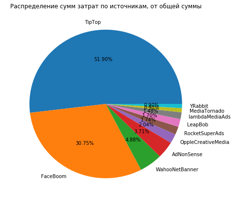

```python
costs.groupby('channel').agg({'costs': 'sum'}).sort_values(by='costs', ascending=False).\
plot(y='costs', kind='pie', figsize=(7, 7), grid=True, legend=False, shadow=False, autopct='%0.2f%%', labeldistance=1.1)
plt.ylabel(' ')
plt.title('Распределение сумм затрат по источникам, от общей суммы')
plt.show()
```

##### Данные о датах

```python
costs['dt'] = pd.to_datetime(costs['dt']).dt.date
costs.info()
```

```
<class 'pandas.core.frame.DataFrame'>
RangeIndex: 1800 entries, 0 to 1799
Data columns (total 3 columns):
 #   Column   Non-Null Count  Dtype
---  ------   --------------  -----
 0   dt       1800 non-null   object
 1   channel  1800 non-null   object
 2   costs    1800 non-null   float64
dtypes: float64(1), object(2)
memory usage: 42.3+ KB
```

##### Данные о рекламных расходах

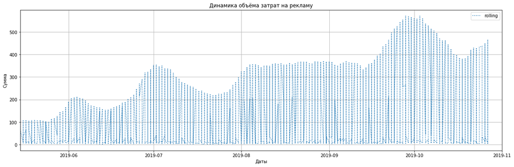

```python
costs['rolling'] = costs['costs'].rolling(7).mean()
costs.plot(x='dt', y='rolling', style=':', grid=True, figsize=(20, 6), xlim=('2019-05-15', '2019-11-01'))
plt.xlabel('Даты')
plt.ylabel('Сумма')
plt.title('Динамика объёма затрат на рекламу')
plt.show()
```

```python
del costs['rolling']
```

**Промежуточные выводы:**

- транзакции по их числу равномерно распределены между 10 каналами;
- при этом по суммам транзакций картина принципиально отлична: более половины пришлось на канал `TipTop`, ещё примерно 30 % - на канал `FaceBoom`, оставшиеся объёмы распределены между оставшимися 8-ю каналами;
- сумма отдельных транзакций волнообразно нарастает; к октябрю средние суммы транзакций увеличиваются в 5 раз: со 100 до 500 единиц;
- изменили форматы данных о датах;
- в целом данные корректны, готовы к анализу.

### Задание функций

Функция `get_profiles` для создания пользовательских профилей:

```python
def get_profiles(sessions, orders, costs):

    # находим параметры первых посещений
    profiles = (
        sessions.sort_values(by=['user_id', 'session_start'])
        .groupby('user_id')
        .agg(
            {
                'session_start': 'first',
                'channel': 'first',
                'device': 'first',
                'region': 'first',
            }
        )
        .rename(columns={'session_start': 'first_ts'})
        .reset_index()
    )

    # для когортного анализа определяем дату первого посещения
    # и первый день месяца, в который это посещение произошло
    profiles['dt'] = profiles['first_ts'].dt.date
    profiles['month'] = profiles['first_ts'].astype('datetime64[M]')

    # добавляем признак платящих пользователей
    profiles['payer'] = profiles['user_id'].isin(orders['user_id'].unique())

    # считаем количество уникальных пользователей
    # с одинаковыми источником и датой привлечения
    new_users = (
        profiles.groupby(['dt', 'channel'])
        .agg({'user_id': 'nunique'})
        .rename(columns={'user_id': 'unique_users'})
        .reset_index()
    )

    # объединяем траты на рекламу и число привлечённых пользователей
    costs = costs.merge(new_users, on=['dt', 'channel'], how='left')

    # делим рекламные расходы на число привлечённых пользователей
    costs['acquisition_cost'] = costs['costs'] / costs['unique_users']

    # добавляем стоимость привлечения в профили
    profiles = profiles.merge(
        costs[['dt', 'channel', 'acquisition_cost']],
        on=['dt', 'channel'],
        how='left',
    )

    # стоимость привлечения органических пользователей равна нулю
    profiles['acquisition_cost'] = profiles['acquisition_cost'].fillna(0)

    return profiles
```

Функция `get_retention` для расчёта удержания:

```python
def get_retention(
    profiles,
    sessions,
    observation_date,
    horizon_days,
    dimensions=[],
    ignore_horizon=False,
):

    # добавляем столбец payer в передаваемый dimensions список
    dimensions = ['payer'] + dimensions

    # исключаем пользователей, не «доживших» до горизонта анализа
    last_suitable_acquisition_date = observation_date
    if not ignore_horizon:
        last_suitable_acquisition_date = observation_date - timedelta(
            days=horizon_days - 1
        )
    result_raw = profiles.query('dt <= @last_suitable_acquisition_date')

    # собираем «сырые» данные для расчёта удержания
    result_raw = result_raw.merge(
        sessions[['user_id', 'session_start']], on='user_id', how='left'
    )
    result_raw['lifetime'] = (
        result_raw['session_start'] - result_raw['first_ts']
    ).dt.days

    # функция для группировки таблицы по желаемым признакам
    def group_by_dimensions(df, dims, horizon_days):
        result = df.pivot_table(
            index=dims, columns='lifetime', values='user_id', aggfunc='nunique'
        )
        cohort_sizes = (
            df.groupby(dims)
            .agg({'user_id': 'nunique'})
            .rename(columns={'user_id': 'cohort_size'})
        )
        result = cohort_sizes.merge(result, on=dims, how='left').fillna(0)
        result = result.div(result['cohort_size'], axis=0)
        result = result[['cohort_size'] + list(range(horizon_days))]
        result['cohort_size'] = cohort_sizes
        return result

    # получаем таблицу удержания
    result_grouped = group_by_dimensions(result_raw, dimensions, horizon_days)

    # получаем таблицу динамики удержания
    result_in_time = group_by_dimensions(
        result_raw, dimensions + ['dt'], horizon_days
    )

    # возвращаем обе таблицы и сырые данные
    return result_raw, result_grouped, result_in_time
```

Функция `get_conversion` для расчёта конверсии:

```python
def get_conversion(
    profiles,
    orders,
    observation_date,
    horizon_days,
    dimensions=[],
    ignore_horizon=False,
):

    # исключаем пользователей, не «доживших» до горизонта анализа
    last_suitable_acquisition_date = observation_date
    if not ignore_horizon:
        last_suitable_acquisition_date = observation_date - timedelta(
            days=horizon_days - 1
        )
    result_raw = profiles.query('dt <= @last_suitable_acquisition_date')

    # определяем дату и время первой покупки для каждого пользователя
    first_purchases = (
        orders.sort_values(by=['user_id', 'event_dt'])
        .groupby('user_id')
        .agg({'event_dt': 'first'})
        .reset_index()
    )

    # добавляем данные о покупках в профили
    result_raw = result_raw.merge(
        first_purchases[['user_id', 'event_dt']], on='user_id', how='left'
    )

    # рассчитываем лайфтайм для каждой покупки
    result_raw['lifetime'] = (
        result_raw['event_dt'] - result_raw['first_ts']
    ).dt.days

    # группируем по cohort, если в dimensions ничего нет
    if len(dimensions) == 0:
        result_raw['cohort'] = 'All users'
        dimensions = dimensions + ['cohort']

    # функция для группировки таблицы по желаемым признакам
    def group_by_dimensions(df, dims, horizon_days):
        result = df.pivot_table(
            index=dims, columns='lifetime', values='user_id', aggfunc='nunique'
        )
        result = result.fillna(0).cumsum(axis = 1)
        cohort_sizes = (
            df.groupby(dims)
            .agg({'user_id': 'nunique'})
            .rename(columns={'user_id': 'cohort_size'})
        )
        result = cohort_sizes.merge(result, on=dims, how='left').fillna(0)
        # делим каждую «ячейку» в строке на размер когорты
        # и получаем conversion rate
        result = result.div(result['cohort_size'], axis=0)
        result = result[['cohort_size'] + list(range(horizon_days))]
        result['cohort_size'] = cohort_sizes
        return result

    # получаем таблицу конверсии
    result_grouped = group_by_dimensions(result_raw, dimensions, horizon_days)

    # для таблицы динамики конверсии убираем 'cohort' из dimensions
    if 'cohort' in dimensions:
        dimensions = []

    # получаем таблицу динамики конверсии
    result_in_time = group_by_dimensions(
        result_raw, dimensions + ['dt'], horizon_days
    )

    # возвращаем обе таблицы и сырые данные
    return result_raw, result_grouped, result_in_time
```

Функция `get_ltv` для расчёта LTV и ROI:

```python
def get_ltv(
    profiles,
    orders,
    observation_date,
    horizon_days,
    dimensions=[],
    ignore_horizon=False,
):

    # исключаем пользователей, не «доживших» до горизонта анализа
    last_suitable_acquisition_date = observation_date
    if not ignore_horizon:
        last_suitable_acquisition_date = observation_date - timedelta(
            days=horizon_days - 1
        )
    result_raw = profiles.query('dt <= @last_suitable_acquisition_date')
    # добавляем данные о покупках в профили
    result_raw = result_raw.merge(
        orders[['user_id', 'event_dt', 'revenue']], on='user_id', how='left'
    )
    # рассчитываем лайфтайм пользователя для каждой покупки
    result_raw['lifetime'] = (
        result_raw['event_dt'] - result_raw['first_ts']
    ).dt.days
    # группируем по cohort, если в dimensions ничего нет
    if len(dimensions) == 0:
        result_raw['cohort'] = 'All users'
        dimensions = dimensions + ['cohort']

    # функция группировки по желаемым признакам
    def group_by_dimensions(df, dims, horizon_days):
        # строим «треугольную» таблицу выручки
        result = df.pivot_table(
            index=dims, columns='lifetime', values='revenue', aggfunc='sum'
        )
        # находим сумму выручки с накоплением
        result = result.fillna(0).cumsum(axis=1)
        # вычисляем размеры когорт
        cohort_sizes = (
            df.groupby(dims)
            .agg({'user_id': 'nunique'})
            .rename(columns={'user_id': 'cohort_size'})
        )
        # объединяем размеры когорт и таблицу выручки
        result = cohort_sizes.merge(result, on=dims, how='left').fillna(0)
        # считаем LTV: делим каждую «ячейку» в строке на размер когорты
        result = result.div(result['cohort_size'], axis=0)
        # исключаем все лайфтаймы, превышающие горизонт анализа
        result = result[['cohort_size'] + list(range(horizon_days))]
        # восстанавливаем размеры когорт
        result['cohort_size'] = cohort_sizes

        # собираем датафрейм с данными пользователей и значениями CAC,
        # добавляя параметры из dimensions
        cac = df[['user_id', 'acquisition_cost'] + dims].drop_duplicates()

        # считаем средний CAC по параметрам из dimensions
        cac = (
            cac.groupby(dims)
            .agg({'acquisition_cost': 'mean'})
            .rename(columns={'acquisition_cost': 'cac'})
        )

        # считаем ROI: делим LTV на CAC
        roi = result.div(cac['cac'], axis=0)

        # удаляем строки с бесконечным ROI
        roi = roi[~roi['cohort_size'].isin([np.inf])]

        # восстанавливаем размеры когорт в таблице ROI
        roi['cohort_size'] = cohort_sizes

        # добавляем CAC в таблицу ROI
        roi['cac'] = cac['cac']

        # в финальной таблице оставляем размеры когорт, CAC
        # и ROI в лайфтаймы, не превышающие горизонт анализа
        roi = roi[['cohort_size', 'cac'] + list(range(horizon_days))]

        # возвращаем таблицы LTV и ROI
        return result, roi

    # получаем таблицы LTV и ROI
    result_grouped, roi_grouped = group_by_dimensions(
        result_raw, dimensions, horizon_days
    )

    # для таблиц динамики убираем 'cohort' из dimensions
    if 'cohort' in dimensions:
        dimensions = []

    # получаем таблицы динамики LTV и ROI
    result_in_time, roi_in_time = group_by_dimensions(
        result_raw, dimensions + ['dt'], horizon_days
    )

    return (
        result_raw,  # сырые данные
        result_grouped,  # таблица LTV
        result_in_time,  # таблица динамики LTV
        roi_grouped,  # таблица ROI
        roi_in_time,  # таблица динамики ROI
    )
```

Функция `filter_data` для сглаживания фрейма:

```python
def filter_data(df, window):
    # для каждого столбца применяем скользящее среднее
    for column in df.columns.values:
        df[column] = df[column].rolling(window).mean()
    return df
```

Функция `plot_retention` для визуализации удержания:

```python
def plot_retention(retention, retention_history, horizon, window=7):

    # задаём размер сетки для графиков
    plt.figure(figsize=(15, 10))

    # исключаем размеры когорт и удержание первого дня
    retention = retention.drop(columns=['cohort_size', 0])
    # в таблице динамики оставляем только нужный лайфтайм
    retention_history = retention_history.drop(columns=['cohort_size'])[
        [horizon - 1]
    ]

    # если в индексах таблицы удержания только payer,
    # добавляем второй признак — cohort
    if retention.index.nlevels == 1:
        retention['cohort'] = 'All users'
        retention = retention.reset_index().set_index(['cohort', 'payer'])

    # в таблице графиков — два столбца и две строки, четыре ячейки
    # в первой строим кривые удержания платящих пользователей
    ax1 = plt.subplot(2, 2, 1)
    retention.query('payer == True').T.plot(
        grid=True, ax=ax1
    )
    plt.legend()
    plt.xlabel('Лайфтайм')
    plt.title('Удержание платящих пользователей')

    # во второй ячейке строим кривые удержания неплатящих
    # вертикальная ось — от графика из первой ячейки
    ax2 = plt.subplot(2, 2, 2, sharey=ax1)
    retention.query('payer == False').T.plot(
        grid=True, ax=ax2
    )
    plt.legend()
    plt.xlabel('Лайфтайм')
    plt.title('Удержание неплатящих пользователей')

    # в третьей ячейке — динамика удержания платящих
    ax3 = plt.subplot(2, 2, 3)
    # получаем названия столбцов для сводной таблицы
    columns = [
        name
        for name in retention_history.index.names
        if name not in ['dt', 'payer']
    ]
    # фильтруем данные и строим график
    filtered_data = retention_history.query('payer == True').pivot_table(
        index='dt', columns=columns, values=horizon - 1, aggfunc='mean'
    )
    filter_data(filtered_data, window).plot(grid=True, ax=ax3)
    plt.xlabel('Дата привлечения')
    plt.title(
        'Динамика удержания платящих пользователей на {}-й день'.format(
            horizon
        )
    )

    # в чётвертой ячейке — динамика удержания неплатящих
    ax4 = plt.subplot(2, 2, 4, sharey=ax3)
    # фильтруем данные и строим график
    filtered_data = retention_history.query('payer == False').pivot_table(
        index='dt', columns=columns, values=horizon - 1, aggfunc='mean'
    )
    filter_data(filtered_data, window).plot(grid=True, ax=ax4)
    plt.xlabel('Дата привлечения')
    plt.title(
        'Динамика удержания неплатящих пользователей на {}-й день'.format(
            horizon
        )
    )

    plt.tight_layout()
    plt.show()
```

Функция `plot_conversion` для визуализации конверсии.

```python
def plot_conversion(conversion, conversion_history, horizon, window=7):

    # задаём размер сетки для графиков
    plt.figure(figsize=(15, 5))

    # исключаем размеры когорт
    conversion = conversion.drop(columns=['cohort_size'])
    # в таблице динамики оставляем только нужный лайфтайм
    conversion_history = conversion_history.drop(columns=['cohort_size'])[
        [horizon - 1]
    ]

    # первый график — кривые конверсии
    ax1 = plt.subplot(1, 2, 1)
    conversion.T.plot(grid=True, ax=ax1)
    plt.legend()
    plt.xlabel('Лайфтайм')
    plt.title('Конверсия пользователей')

    # второй график — динамика конверсии
    ax2 = plt.subplot(1, 2, 2, sharey=ax1)
    columns = [
        # столбцами сводной таблицы станут все столбцы индекса, кроме даты
        name for name in conversion_history.index.names if name not in ['dt']
    ]
    filtered_data = conversion_history.pivot_table(
        index='dt', columns=columns, values=horizon - 1, aggfunc='mean'
    )
    filter_data(filtered_data, window).plot(grid=True, ax=ax2)
    plt.xlabel('Дата привлечения')
    plt.title('Динамика конверсии пользователей на {}-й день'.format(horizon))

    plt.tight_layout()
    plt.show()
```

Функция `plot_ltv_roi` для визуализации LTV и ROI:

```python
def plot_ltv_roi(ltv, ltv_history, roi, roi_history, horizon, window=7):

    # задаём сетку отрисовки графиков
    plt.figure(figsize=(20, 10))

    # из таблицы ltv исключаем размеры когорт
    ltv = ltv.drop(columns=['cohort_size'])
    # в таблице динамики ltv оставляем только нужный лайфтайм
    ltv_history = ltv_history.drop(columns=['cohort_size'])[[horizon - 1]]

    # стоимость привлечения запишем в отдельный фрейм
    cac_history = roi_history[['cac']]

    # из таблицы roi исключаем размеры когорт и cac
    roi = roi.drop(columns=['cohort_size', 'cac'])
    # в таблице динамики roi оставляем только нужный лайфтайм
    roi_history = roi_history.drop(columns=['cohort_size', 'cac'])[
        [horizon - 1]
    ]

    # первый график — кривые ltv
    ax1 = plt.subplot(2, 3, 1)
    ltv.T.plot(grid=True, ax=ax1)
    plt.legend()
    plt.xlabel('Лайфтайм')
    plt.title('LTV')

    # второй график — динамика ltv
    ax2 = plt.subplot(2, 3, 2, sharey=ax1)
    # столбцами сводной таблицы станут все столбцы индекса, кроме даты
    columns = [name for name in ltv_history.index.names if name not in ['dt']]
    filtered_data = ltv_history.pivot_table(
        index='dt', columns=columns, values=horizon - 1, aggfunc='mean'
    )
    filter_data(filtered_data, window).plot(grid=True, ax=ax2)
    plt.xlabel('Дата привлечения')
    plt.title('Динамика LTV пользователей на {}-й день'.format(horizon))

    # третий график — динамика cac
    ax3 = plt.subplot(2, 3, 3, sharey=ax1)
    # столбцами сводной таблицы станут все столбцы индекса, кроме даты
    columns = [name for name in cac_history.index.names if name not in ['dt']]
    filtered_data = cac_history.pivot_table(
        index='dt', columns=columns, values='cac', aggfunc='mean'
    )
    filter_data(filtered_data, window).plot(grid=True, ax=ax3)
    plt.xlabel('Дата привлечения')
    plt.title('Динамика стоимости привлечения пользователей')

    # четвёртый график — кривые roi
    ax4 = plt.subplot(2, 3, 4)
    roi.T.plot(grid=True, ax=ax4)
    plt.axhline(y=1, color='red', linestyle='--', label='Уровень окупаемости')
    plt.legend()
    plt.xlabel('Лайфтайм')
    plt.title('ROI')

    # пятый график — динамика roi
    ax5 = plt.subplot(2, 3, 5, sharey=ax4)
    # столбцами сводной таблицы станут все столбцы индекса, кроме даты
    columns = [name for name in roi_history.index.names if name not in ['dt']]
    filtered_data = roi_history.pivot_table(
        index='dt', columns=columns, values=horizon - 1, aggfunc='mean'
    )
    filter_data(filtered_data, window).plot(grid=True, ax=ax5)
    plt.axhline(y=1, color='red', linestyle='--', label='Уровень окупаемости')
    plt.xlabel('Дата привлечения')
    plt.title('Динамика ROI пользователей на {}-й день'.format(horizon))

    plt.tight_layout()
    plt.show()
```

**Промежуточные выводы:**

- задали функции для дальнейших расчётов.

### Исследовательский анализ данных

#### Профили пользователей

Составили профили пользователей. Определили минимальную и максимальную даты привлечения пользователей.

```python
profiles = get_profiles(sessions, orders, costs)
profiles.head()
```

|  | user_id | first_ts | channel | device | region | dt | month | payer | acquisition_cost |
| --- | --- | --- | --- | --- | --- | --- | --- | --- | --- |
| 0 | 599326 | 2019-05-07 20:58:57 | FaceBoom | Mac | United States | 2019-05-07 | 2019-05-01 | True | 1.088172 |
| 1 | 4919697 | 2019-07-09 12:46:07 | FaceBoom | iPhone | United States | 2019-07-09 | 2019-07-01 | False | 1.107237 |
| 2 | 6085896 | 2019-10-01 09:58:33 | organic | iPhone | France | 2019-10-01 | 2019-10-01 | False | 0.000000 |
| 3 | 22593348 | 2019-08-22 21:35:48 | AdNonSense | PC | Germany | 2019-08-22 | 2019-08-01 | False | 0.988235 |
| 4 | 31989216 | 2019-10-02 00:07:44 | YRabbit | iPhone | United States | 2019-10-02 | 2019-10-01 | False | 0.230769 |

```python
min_dt = profiles['dt'].min()
max_dt = profiles['dt'].max()
print(f'Минимальная дата привлечения пользователей: {min_dt}.\nМаксимальная дата привлечения пользователей: {max_dt}.')
```

```
Минимальная дата привлечения пользователей: 2019-05-01.
Максимальная дата привлечения пользователей: 2019-10-27.
```

Результаты соответствуют исходным данным.

#### Страны пользователей

Выяснили, из каких стран пользователи приходят в приложение и на какую страну приходится больше всего платящих пользователей.

Построили таблицу, отражающую количество пользователей и долю платящих из каждой страны.

```python
print('Пользователи приходят из:')
list(profiles['region'].unique())
```

```
Пользователи приходят из:
```

```
['United States', 'France', 'Germany', 'UK']
```

```python
country_payers = profiles.groupby('region').agg({'user_id': 'nunique', 'payer': ['sum', 'mean']})
country_payers.columns = ['users', 'payers', 'pay_share']
country_payers.sort_values(by='users', ascending=False).style.format({'pay_share':'{:.2%}'})
```

| region | users | payers | pay_share |
| --- | --- | --- | --- |
| United States | 100002 | 6902 | 6.90% |
| UK | 17575 | 700 | 3.98% |
| France | 17450 | 663 | 3.80% |
| Germany | 14981 | 616 | 4.11% |

Больше всего платящих пользователей приходится на США. Доля платящих пользователей также выше в этой стране.

#### Устройства пользователей

Узнали, какими устройствами пользуются клиенты и какие устройства предпочитают платящие пользователи.

Построили таблицу, отражающую количество пользователей и долю платящих для каждого устройства.

```python
print('Пользователи используют устройства:')
list(profiles['device'].unique())
```

```
Пользователи используют устройства:
```

```
['Mac', 'iPhone', 'PC', 'Android']
```

```python
devices = profiles.groupby('device').agg({'user_id': 'nunique', 'payer': ['sum', 'mean']})
devices.columns = ['users', 'payers', 'pay_share']
devices.sort_values(by='users', ascending=False).style.format({'pay_share':'{:.2%}'})
```

| device | users | payers | pay_share |
| --- | --- | --- | --- |
| iPhone | 54479 | 3382 | 6.21% |
| Android | 35032 | 2050 | 5.85% |
| PC | 30455 | 1537 | 5.05% |
| Mac | 30042 | 1912 | 6.36% |

Наиболее популярное устройство пользователей - `iPhone`. Доля платящих при этом чуть выше у пользователей `Mac`.

#### Рекламные источники

Изучили рекламные источники привлечения и определили каналы, из которых пришло больше всего платящих пользователей.

Построили таблицу, отражающую количество пользователей и долю платящих для каждого канала привлечения.

```python
channels = profiles.groupby('channel').agg({'user_id': 'nunique', 'payer': ['sum', 'mean']})
channels.columns = ['users', 'payers', 'pay_share']
channels.sort_values(by='pay_share', ascending=False).style.format({'pay_share':'{:.2%}'})
```

| channel | users | payers | pay_share |
| --- | --- | --- | --- |
| FaceBoom | 29144 | 3557 | 12.20% |
| AdNonSense | 3880 | 440 | 11.34% |
| lambdaMediaAds | 2149 | 225 | 10.47% |
| TipTop | 19561 | 1878 | 9.60% |
| RocketSuperAds | 4448 | 352 | 7.91% |
| WahooNetBanner | 8553 | 453 | 5.30% |
| YRabbit | 4312 | 165 | 3.83% |
| MediaTornado | 4364 | 156 | 3.57% |
| LeapBob | 8553 | 262 | 3.06% |
| OppleCreativeMedia | 8605 | 233 | 2.71% |
| organic | 56439 | 1160 | 2.06% |

**Промежуточные выводы:**

### Маркетинг

```python
costs.head(3)
```

|  | dt | channel | costs |
| --- | --- | --- | --- |
| 0 | 2019-05-01 | FaceBoom | 113.3 |
| 1 | 2019-05-02 | FaceBoom | 78.1 |
| 2 | 2019-05-03 | FaceBoom | 85.8 |

#### Общие расходы

Посчитали общую сумму расходов на маркетинг.

```python
total_costs = round(costs['costs'].sum(), 2)
print(f'Общая сумма расходов на маркетинг: {total_costs}')
```

```
Общая сумма расходов на маркетинг: 105497.3
```

#### Рекламные источники

Выяснили, как траты распределены по рекламным источникам, то есть сколько денег потратили на каждый источник.

```python
costs.groupby('channel').agg({'costs': 'sum'}).sort_values(by='costs', ascending=False)
```

| channel | costs |
| --- | --- |
| TipTop | 54751.30 |
| FaceBoom | 32445.60 |
| WahooNetBanner | 5151.00 |
| AdNonSense | 3911.25 |
| OppleCreativeMedia | 2151.25 |
| RocketSuperAds | 1833.00 |
| LeapBob | 1797.60 |
| lambdaMediaAds | 1557.60 |
| MediaTornado | 954.48 |
| YRabbit | 944.22 |

#### Динамика изменения расходов

Построили визуализацию динамики изменения расходов во времени (по неделям и месяцам) по каждому источнику.

```python
costs['week'] = pd.to_datetime(costs['dt']).dt.week
costs['month'] = pd.to_datetime(costs['dt']).dt.month
```

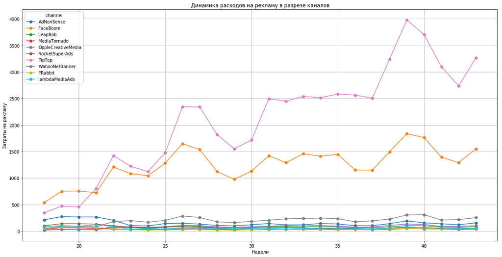

```python
costs.pivot_table(index='week', columns='channel', values='costs', aggfunc='sum').\
plot(figsize=(20, 10),
     style='-o',
     grid=True,
     legend=True)
plt.xlabel('Недели')
plt.ylabel('Затраты на рекламу')
plt.title('Динамика расходов на рекламу в разрезе каналов')
plt.show()
```

Для наглядности продублировали график, исключив доминирующие каналы: `FaceBoom` и `TipTop`.

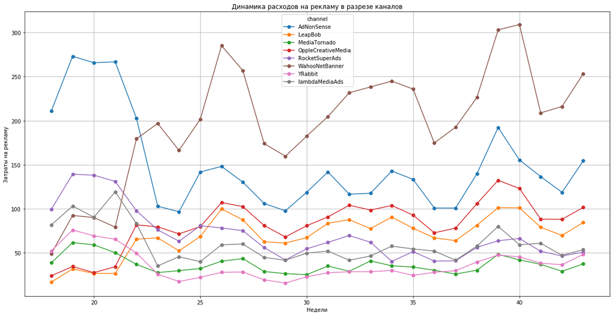

```python
costs.query('channel != "FaceBoom" & channel != "TipTop"').\
pivot_table(index='week', columns='channel', values='costs', aggfunc='sum').\
plot(figsize=(20, 10),
     style='-o',
     grid=True,
     legend=True)
plt.xlabel('Недели')
plt.ylabel('Затраты на рекламу')
plt.title('Динамика расходов на рекламу в разрезе каналов')
plt.show()
```

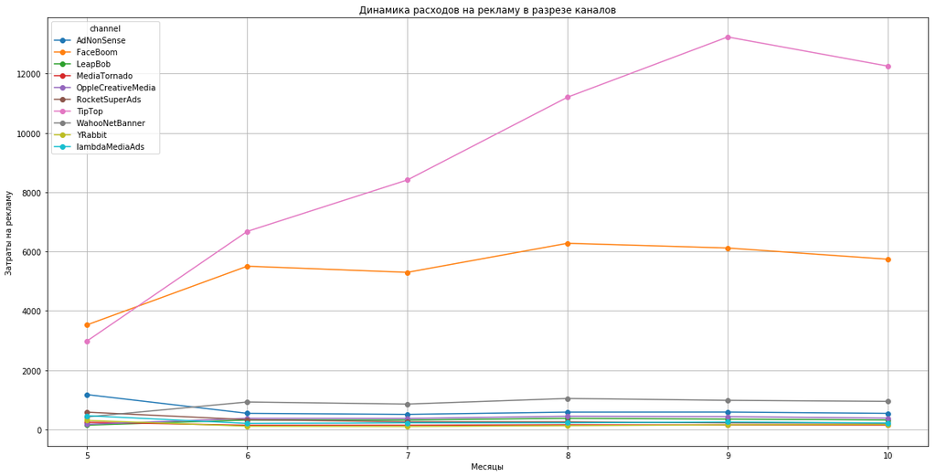

```python
costs.pivot_table(index='month', columns='channel', values='costs', aggfunc='sum').\
plot(figsize=(20, 10),
     style='-o',
     grid=True,
     legend=True)
plt.xlabel('Месяцы')
plt.ylabel('Затраты на рекламу')
plt.title('Динамика расходов на рекламу в разрезе каналов')
plt.show()
```

#### Затраты на привлечение одного пользователя

Узнали, сколько в среднем стоило привлечение одного пользователя (CAC) из каждого источника.

```python
av_cac = profiles.groupby('channel').agg({'acquisition_cost': 'mean'}).sort_values(by='acquisition_cost', ascending=False)
av_cac
```

| channel | acquisition_cost |
| --- | --- |
| TipTop | 2.799003 |
| FaceBoom | 1.113286 |
| AdNonSense | 1.008054 |
| lambdaMediaAds | 0.724802 |
| WahooNetBanner | 0.602245 |
| RocketSuperAds | 0.412095 |
| OppleCreativeMedia | 0.250000 |
| YRabbit | 0.218975 |
| MediaTornado | 0.218717 |
| LeapBob | 0.210172 |
| organic | 0.000000 |

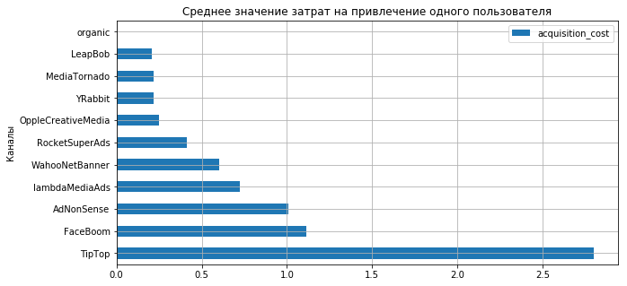

```python
av_cac.plot(kind='barh', figsize=(10, 5), grid=True, legend=True, rot=0)
plt.ylabel('Каналы')
plt.title('Среднее значение затрат на привлечение одного пользователя')
plt.show()
```

В среднем самый дорогой привлечённый пользователь - с платформы `TipTop`.

**Промежуточные выводы:**

- посчитали общую сумму расходов на маркетинг: 105497.3 единиц;
- выяснили, как траты распределены по рекламным источникам, то есть сколько денег потратили на каждый источник; наибольшая сумма потрачена на источник `TipTop` 54751.30 единиц;
- построили визуализацию динамики изменения расходов во времени (по неделям и месяцам) по каждому источнику;
- узнали, сколько в среднем стоило привлечение одного пользователя (CAC) из каждого источника; в среднем самый дорогой привлечённый пользователь - с платформы `TipTop`.

### Оценка окупаемость рекламы

Проанализировали окупаемость рекламы.

Дата анализа: 1 ноября 2019 года, пользователи должны окупаться не позднее чем через две недели после привлечения.

Данные об органических пользователях **исключили**:

```python
profiles = profiles.query('channel != "organic"')
user_id_clean = list(profiles['user_id'])
orders = orders.query('user_id in @user_id_clean')
sessions = sessions.query('user_id in @user_id_clean')
```

```python
observation_date = datetime(2019, 11, 1).date()
horizon_days = 14
```

```python
orders['revenue_sum'] = orders['revenue'].cumsum(axis=0)
costs['costs_sum'] = costs['costs'].cumsum(axis=0)
```

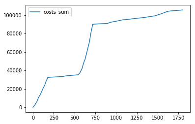

```python
costs.plot(y='costs_sum')
```

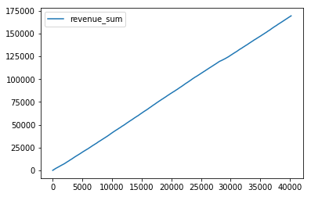

```python
orders.plot(y='revenue_sum')
```

#### Анализ конверсии

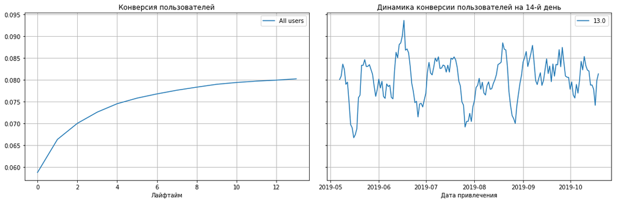

```python
conversion_raw, conversion, conversion_history = get_conversion(
    profiles,
    orders,
    observation_date,
    horizon_days,
    dimensions=[],
    ignore_horizon=False,
)
plot_conversion(conversion, conversion_history, horizon_days, window=7)
```

Конверсия около 8 %, значение на 14-ый день колеблется в коридоре 7-9,5 %.

#### Анализ удержания

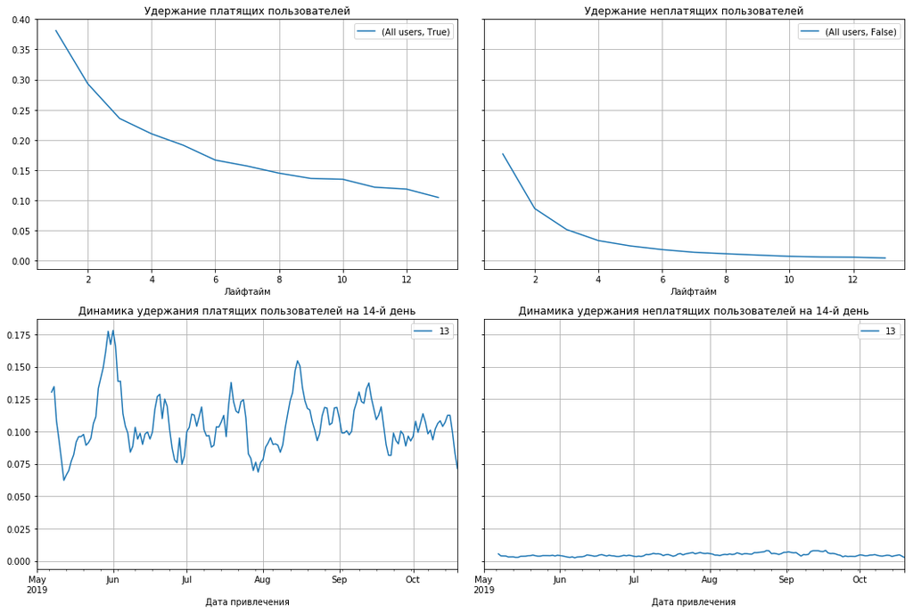

```python
retention_raw, retention, retention_history = get_retention(
    profiles,
    sessions,
    observation_date,
    horizon_days,
    dimensions=[],
    ignore_horizon=False,
)
plot_retention(retention, retention_history, horizon_days, window=7)
```

Удержание имеет средние значения; неплатящие практически не удерживаются до 14-го дня.

#### Анализ окупаемости рекламы

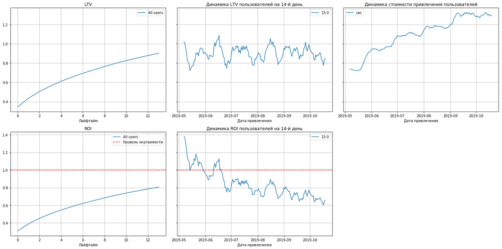

```python
ltv_raw, ltv_grouped, ltv_history, roi_grouped, roi_history = get_ltv(profiles, orders, observation_date, horizon_days)
plot_ltv_roi(ltv_grouped, ltv_history, roi_grouped, roi_history, horizon_days)
```

Реклама не окупается. ROI в конце периода около 80 %.

CAC скачкообразно возрастает с середины мая, продолжает расти до конца периода анализа.

В мая же наблюдается резкое снижение ROI пользователей 14-го дня. С середины июня вложения перестают окупаться.

LTV колеблется в районе отметки 0,9, то возрастая, то убывая. Это означает, что "качество" пользователей остаётся примерно одинаковым.